# Adult and child longevity in relation to sanitation in developing countries: Revisited

- Introduction
- Data Wrangling
- Exploratory Data Analysis
- Conclusions

# A brief intro since this is a Revisit

## Introduction

Gapminder was chosen for this data analysis. This set has information about indicators including but not limited to:

- Economics
- Population
- Work
- Infrastructure
- Health

**For the purpose of this project, longevity against sanitation is investigated.**

**Three variables related to health were chosen against overall access to sanitation:**

**1 - Child mortality (0-5 years old)/1000 children**

**2 - Male life expectancy**

**3 - Female life expectancy**

Overall sanitation dataset was found out to cover data **only for 2000 to 2017.**

Contrarily, child mortality covers 1800 to 2100, and both life expectancy sets cover 1950 to 2099.

Therefore, **only the period 2000 to 2017** has been chosen for investigation for **all datasets.**

**We ask the three following questions:**

- **Question 1: How does sanitation change over the years?**
- **Question 2: How does change in sanitation correlate with longevity in children and adults?**
- **Question 3: Does change in sanitation affect male and female longevity differently?**

## Assessing

- Inconsistencies in rows number
- NaN values in sanitation

## Cleaning

- reset according to the lowest rows number
- Only sanitation has nan. So, will be replaced with zeros. We shall conduct this analysis considering that unreported sanitation access percentage is zero. Additionally, the number of nan in a columns could be at most 8. Since we shall use means for visualizations, the error that would result is acceptable.

```
country    0
2000       0
2001       0
2002       0
2003       0
2004       0
2005       0
2006       0
2007       0
2008       0
2009       0
2010       0
2011       0
2012       0
2013       0
2014       0
2015       0
2016       0
2017       0
dtype: int64
```

## Conclusions

**Now, back to our initial questions:**

- **Question 1: How does sanitation change over the years?**
- **Question 2: How does change in sanitation correlate with longevity in children and adults?**
- **Question 3: Does change in sanitation affect male and female longevity differently?**

### Question 1: How does sanitation change over the years?**

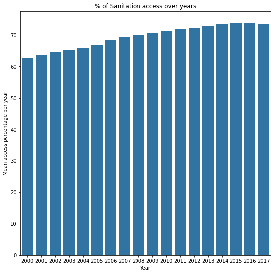

### We found the mean access to increase from about 63 in 2000 to about 74 in 2015. Then there was a slight drop in 2016 and 2017.

### Question 2: How does change in sanitation correlate with longevity in children and adults?

#### 1- There is a very clear drop in child mortality from 58 to 30

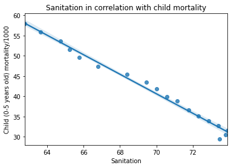

#### 2- Male expectancy clearly increases from 63 to 69

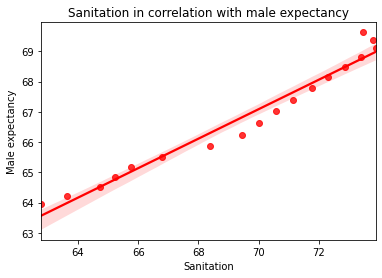

#### 3- Female expectancy clearly increases from 69 to 74

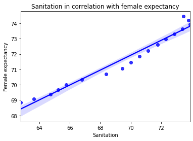

### Question 3: Does change in sanitation affect male and female longevity differently?

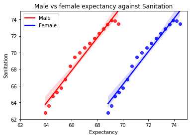

- ### There is no significant difference. It was eleveated for both by about 4 - 5 years, which is likely due to the similar positive effect of sanitataion on both. However, females had higher expectancy in the beginning.

## Thus, the final conclusion is that better sanitaion, as expected, correlates positively with male and female expectancy, and negatively with child mortality. Therefore, it is likely that sanitation correlates with better longevity.

## Limitations

**The previous conclusions could be undermined by some limitations including:**

- NaN values in sanitation dataset. Although few, replacing them by zeros could impact the obtained means. They also affect all correspondences equally.
- Analysis was according to years, so the changes for each individual country cannot be measured.